# STA6235 - Project 3 Assignment

Gabriel Rivera Alvarez

2022-08-07

## Libraries Used

```r
# Libraries to be used
library(tidyverse)
library(car)
library(olsrr)
library(lindia)
library(MASS)
```

## Dataset Reading

```r
# Load dataset
data <- read.csv("/Users/gabrielrivera/Documents/Maestria/Courses/4- Summer 2022/STA6235/Project 3/Walmart_Store_sales.csv")
```

## Dataset Display

```r
#Display first 5 rows of the dataset
head(data,5)
```

```
##   Store       Date Weekly_Sales Holiday_Flag Temperature Fuel_Price      CPI
## 1     1 05-02-2010      1643691            0       42.31      2.572 211.0964
## 2     1 12-02-2010      1641957            1       38.51      2.548 211.2422
## 3     1 19-02-2010      1611968            0       39.93      2.514 211.2891
## 4     1 26-02-2010      1409728            0       46.63      2.561 211.3196
## 5     1 05-03-2010      1554807            0       46.50      2.625 211.3501
##   Unemployment
## 1        8.106
## 2        8.106
## 3        8.106
## 4        8.106
## 5        8.106
```

## Dataset Description

As stated in Project 1 and 2, the dataset being used comes from Kaggle. The link to the dataset is: https://www.kaggle.com/datasets/rutuspatel/walmart-dataset-retail. This dataset contains columns that are: Store, Date, Weekly_Sales, Holiday_Flag, Temperature, Fuel_Price, CPI, and Unemployment. This dataset contains one categorical predictor, which is Holiday_Flag. This will be one of my categorical variables. Since the dataset does not contain another categorical predictor, I will filter the dataset to contain only stores 1 and 2. A categorical predictor will be generated to have Store 1 as 0 and Store 2 as 1. For the continuous predictors, I will be using Temperature and Fuel Price. The combination of this 4 variables will be used to determine a model to see if they are good predictors for the outcome of Weekly Sales.

## Dataset Filtering

```r
# Remove all the rows that do not belong to Store 1 or Store 2
data <- filter(data, Store <=2)
```

## Addition of Categorical Variable Based on Store

```r
# Add Column for categorical variable based on store. Put 0 if store 1 and put 1 if store 2
data$Store_No <- if_else(data$Store == 1, as.integer(0), as.integer(1))
```

## Dataset Extraction and Display

```r
# Put variables of interest as a tibble
dataset <- tibble(WkSales = data$Weekly_Sales, Temp = data$Temperature, Fuel_Price = data$Fuel_Price, Holiday = data$Holiday_Flag, Store_No = data$Store_No)
head(dataset,5)
```

```
## # A tibble: 5 × 5
##    WkSales  Temp Fuel_Price Holiday Store_No
##      <dbl> <dbl>      <dbl>   <int>    <int>
## 1 1643691.  42.3       2.57       0        0
## 2 1641957.  38.5       2.55       1        0
## 3 1611968.  39.9       2.51       0        0
## 4 1409728.  46.6       2.56       0        0
## 5 1554807.  46.5       2.62       0        0
```

## Multiple Linear Regression Model with Interaction

```r
m1 <- lm(WkSales ~ Temp + Fuel_Price + Holiday + Store_No + Holiday:Store_No, data = dataset)
summary(m1)
```

```
##
## Call:
## lm(formula = WkSales ~ Temp + Fuel_Price + Holiday + Store_No +
##     Holiday:Store_No, data = dataset)
##
## Residuals:
##     Min      1Q  Median      3Q     Max
## -361884  -89920  -23271   64283 1459638
##
## Coefficients:
##                   Estimate Std. Error t value Pr(>|t|)
## (Intercept)      1776570.8    96116.2  18.484  < 2e-16 ***
## Temp               -3223.6      802.6  -4.016  7.6e-05 ***
## Fuel_Price         -2137.9    27519.7  -0.078    0.938
## Holiday            82487.1    64010.5   1.289    0.199
## Store_No          367050.3    23699.6  15.488  < 2e-16 ***
## Holiday:Store_No   44976.5    89621.1   0.502    0.616
## ---
## Signif. codes:  0 '***' 0.001 '**' 0.01 '*' 0.05 '.' 0.1 ' ' 1
##
## Residual standard error: 193300 on 280 degrees of freedom
## Multiple R-squared:  0.5088, Adjusted R-squared:    0.5
## F-statistic: 58.01 on 5 and 280 DF,  p-value: < 2.2e-16
```

## Intercept and Slope Extraction for Model with Interaction

```r
lin_coeff <- coefficients(m1)
lin_coeff
```

```
##      (Intercept)             Temp       Fuel_Price          Holiday
##      1776570.821        -3223.566        -2137.889        82487.144
##         Store_No Holiday:Store_No
##       367050.256        44976.477
```

## Resulting Multiple Linear Regression Model with Interaction is:

$$\hat{WkSales} = 1.7765708\times 10^{6}
+ -3223.57*Temp + -2137.89*FuelPrice + 8.248714\times 10^{4}*Holiday +
3.6705026\times 10^{5}*StoreNo + 4.497648\times
10^{4}*Holiday:StoreNo$$

## Multiple Linear Regression Model without Interaction

```r
m2 <- lm(WkSales ~ Temp + Fuel_Price + Holiday + Store_No, data = dataset)
summary(m2)
```

```
##
## Call:
## lm(formula = WkSales ~ Temp + Fuel_Price + Holiday + Store_No,
##     data = dataset)
##
## Residuals:
##     Min      1Q  Median      3Q     Max
## -350256  -93164  -23772   63605 1458041
##
## Coefficients:
##              Estimate Std. Error t value Pr(>|t|)
## (Intercept) 1775065.3    95941.4  18.502  < 2e-16 ***
## Temp          -3225.0      801.5  -4.024 7.38e-05 ***
## Fuel_Price    -2127.7    27483.0  -0.077   0.9383
## Holiday      104960.4    45677.8   2.298   0.0223 *
## Store_No     370195.3    22825.5  16.218  < 2e-16 ***
## ---
## Signif. codes:  0 '***' 0.001 '**' 0.01 '*' 0.05 '.' 0.1 ' ' 1
##
## Residual standard error: 193000 on 281 degrees of freedom
## Multiple R-squared:  0.5084, Adjusted R-squared:  0.5014
## F-statistic: 72.64 on 4 and 281 DF,  p-value: < 2.2e-16
```

## Intercept and Slope Extraction for Model without Interaction

```r
lin_coeff <- coefficients(m2)
lin_coeff
```

```
## (Intercept)        Temp  Fuel_Price     Holiday    Store_No
## 1775065.324   -3225.011   -2127.750  104960.411  370195.334
```

## Resulting Multiple Linear Regression Model without Interaction is:

$$\hat{WkSales} = 1.7750653\times 10^{6}
+ -3225.01*Temp + -2127.75*FuelPrice + 1.0496041\times 10^{5}*Holiday +
3.7019533\times 10^{5}*StoreNo$$

## AIC

```r
AIC_m1 <- AIC(m1)
AIC_m2 <- AIC(m2)
```

## $R^2_{adj}$

```r
s1 <- summary(m1)
Rsqr_m1 <- s1$adj.r.squared
s2 <- summary(m2)
Rsqr_m2 <- s2$adj.r.squared
```

## Tabulated Results

```r
c1 <- c('m1','m2')
c2 <- c(round(AIC_m1,digits=2),round(AIC_m2,digits=2))
c3 <- c(round(Rsqr_m1,digits=5),round(Rsqr_m2,digits=5))
results <- data.frame(c1,c2,c3)
names(results) <- c('Model','AIC','Adjusted R-squared')
results <- as_tibble(results)
results
```

```
## # A tibble: 2 × 3
##   Model   AIC `Adjusted R-squared`
##   <chr> <dbl>                <dbl>
## 1 m1    7782.                0.500
## 2 m2    7780.                0.501
```

## Model Analysis

- The final model selected in Project 2 was the model without the interaction term. Looking at the AIC from the tabulated results, it can be observed that the model without interaction has a value of 7780.10. This value is slightly lower than the 7781.85 AIC value of the model with interaction. The desired model is the model with the lowest AIC. In this case, that model is the model without the interaction term. Based on the AIC results, it can be concluded that the model without interaction (m2) has a slightly better fit. This conclusion goes along with the model selected in Project 2. In both cases, model without interaction is the best model.
- Looking at the $R^2_{adj}$, it can be observed that the model without the interaction has a $R^2_{adj}$ of 0.50136 versus 0.50003 for the model with the interaction term. Based on this, the model with no interaction terms is slightly better $R^2_{adj}$. This means that model with no interactions can account for a slightly higher variability of Weekly Sales compared to the model that contains interactions. Based on $R^2_{adj}$ results, it can be concluded that the model without interaction (m2) has a slightly better fit. This conclusion goes along with the model selected in Project 2 because in both cases the model without interaction is the best model.
- Looking at the individual analysis of AIC and $R^2_{adj}$, it can be observed that in both cases the model without interaction offers a slightly better fit. Comparing this two results in conjuction with the model selected in Project 2, it can be observed that in all three cases the model without interaction terms is choosen because it is a better fit.

## Selected Best Model

$$\hat{WkSales} = 1.7750653\times 10^{6}
+ -3225.01*Temp + -2127.75*FuelPrice + 1.0496041\times 10^{5}*Holiday +
3.7019533\times 10^{5}*StoreNo$$

## Potential Outlier Identification

```r
# Studentized Deleted Residuals
dataset$Stud_Residuals <- studres(m2)

# Residuals Flag Variable
dataset$Residuals_Flag <- if_else(abs(dataset$Stud_Residuals) >= 3, 1 , 0)

# Filter potential outliers
pot_outliers <- dataset %>% filter(Residuals_Flag == 1)
pot_outliers
```

```
## # A tibble: 6 × 7
##    WkSales  Temp Fuel_Price Holiday Store_No Stud_Residuals Residuals_Flag
##      <dbl> <dbl>      <dbl>   <int>    <int>          <dbl>          <dbl>
## 1 2387950.  52.3       2.89       0        0           4.23              1
## 2 2270189.  48.0       3.11       0        0           3.49              1
## 3 2658725.  63.0       2.74       1        1           3.35              1
## 4 2609167.  47.6       2.87       0        1           3.31              1
## 5 3436008.  50.0       2.89       0        1           8.52              1
## 6 3224370.  46.7       3.11       0        1           6.98              1
```

- Potential outliers are identified. Studentized residuals with an absolute value of greater or equal to 3 are considered far enough, and therefore potential outliers. From this analysis, 6 potential outliers are identified.

## Studentized Residuals Visualization

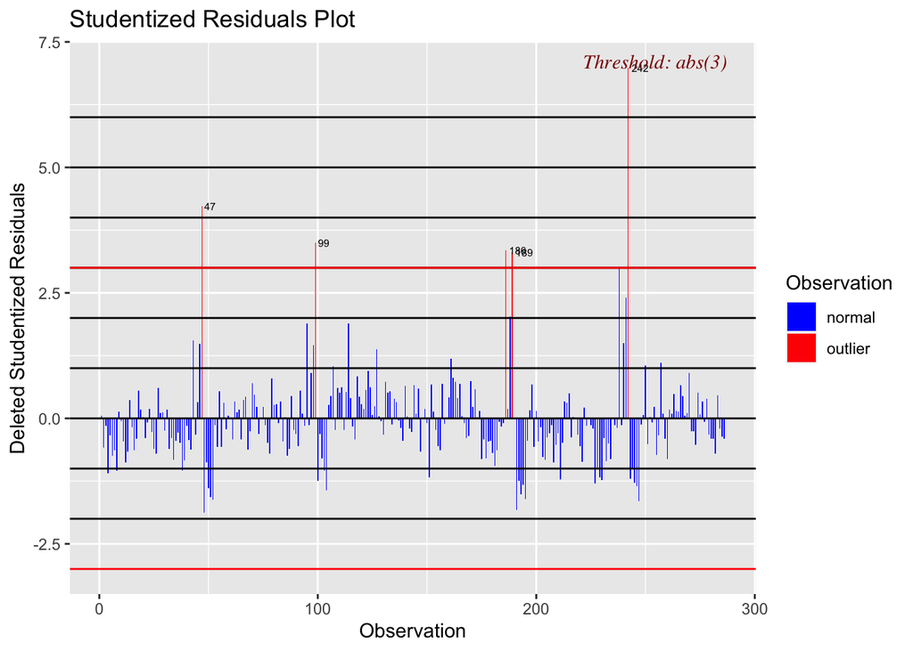

```r
# Plot to help identify the potential outliers determined previously
ols_plot_resid_stud(m2)
```

## Potential Influential/Leverage Points Identification

```r
# Influence Measures
influence_measures <- as_tibble(influence.measures(m2)$infmat)

# Add Cook's Distance to Dataset
dataset$Cook_Dist <- influence_measures$cook.d

# Cook's Distance Flag Variable
dataset$Cook_Dist_Flag <- if_else(abs(dataset$Cook_Dist) >= 4/nrow(dataset), 1 , 0)

# Potential Influential/Leverage Points
pot_influ_lev <- dataset %>% filter(Cook_Dist_Flag == 1)
pot_influ_lev
```

```
## # A tibble: 16 × 9
##     WkSales  Temp Fuel_Price Holiday Store_No Stud_Residuals Residuals_Flag
##       <dbl> <dbl>      <dbl>   <int>    <int>          <dbl>          <dbl>
##  1 1955624.  64.5       2.74       1        0           1.55              0
##  2 2387950.  52.3       2.89       0        0           4.23              1
##  3 1367320.  48.4       2.94       1        0          -1.88              0
##  4 2033321.  60.1       3.24       1        0           1.90              0
##  5 2270189.  48.0       3.11       0        0           3.49              1
##  6 1497463.  44.6       3.13       1        0          -1.24              0
##  7 2658725.  63.0       2.74       1        1           3.35              1
##  8 2378727.  45.5       2.84       0        1           2.03              0
##  9 2609167.  47.6       2.87       0        1           3.31              1
## 10 3436008.  50.0       2.89       0        1           8.52              1
## 11 1750435.  47.3       2.94       1        1          -1.83              0
## 12 1748001.  78.0       3.55       1        1          -1.30              0
## 13 2614202.  56.4       3.24       1        1           2.99              0
## 14 2432737.  50.1       3.16       0        1           2.40              0
## 15 3224370.  46.7       3.11       0        1           6.98              1
## 16 1874227.  44.6       3.13       1        1          -1.20              0
## # … with 2 more variables: Cook_Dist <dbl>, Cook_Dist_Flag <dbl>
```

- Potential influential/leverage points are identified. To do this, Cook’s distance is obtained. Here, distances that are greater than 4/n, or approximately 0.014 based on a sample size of 286, are considered potential influential/leverage points. From this analysis, 16 points fall under that category.

## Cook’s Distance Visualization

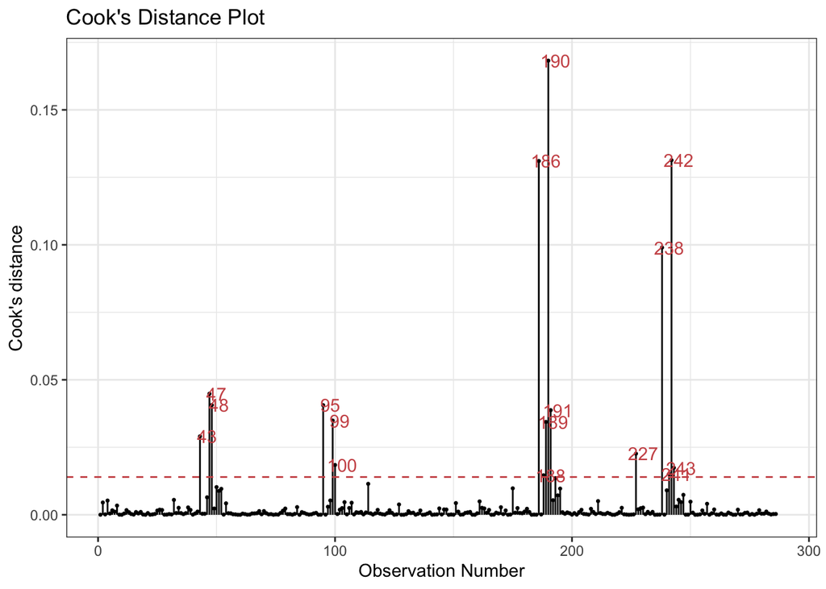

```r
# Plot to help identify the potential influential/leverage points determined previously
gg_cooksd(m2) + theme_bw()
```

## Multicollinearity Assessment

```r
vif(m2)
```

```
##       Temp Fuel_Price    Holiday   Store_No
##   1.085166   1.051464   1.041870   1.000010
```

- Performing a multicollinearity assessment it can be observed that the correlation between the predictors is minimal because all 4 VIF’s are close to 1. This means that because of such small values, it is not expected to have estimation issues due to correlation between predictors.

## Regression Assumptions Assessment

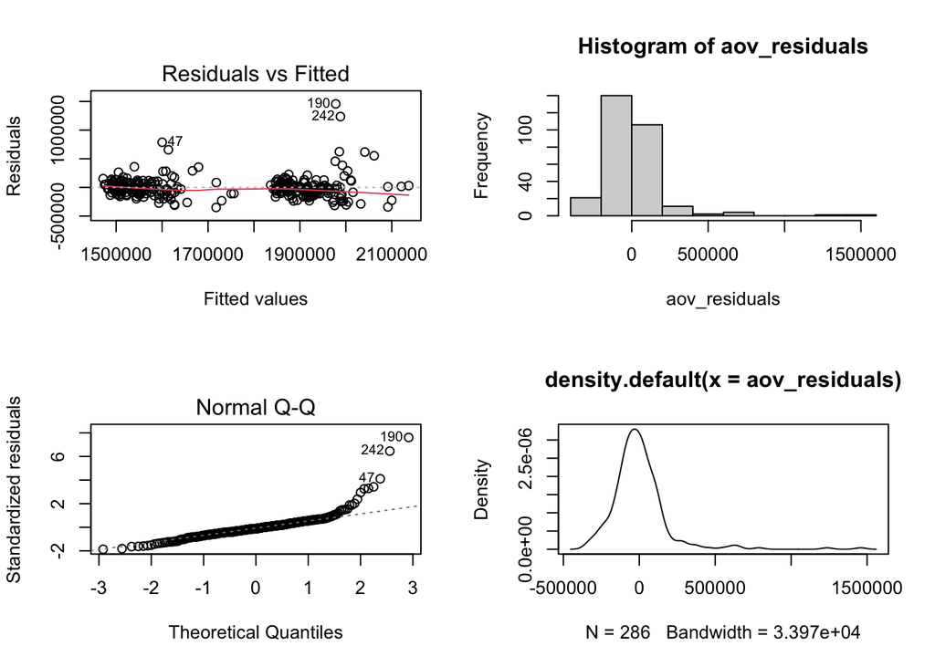

```r
##
almost_sas <- function(aov.results){
  aov_residuals <- residuals(aov.results)
  par(mfrow=c(2,2))
  plot(aov.results, which=1)
  hist(aov_residuals)
  plot(aov.results, which=2)
  plot(density(aov_residuals))
}
almost_sas(m2)
```

## Next Steps

- Perform a sensitivity analysis to remove the problematic data points, re-create the model and see what are the differences between both. To do this the sensitivity analysis would be split in three parts. In the first part only the outliers would be removed, in the second part only the influential/leverage points and lastly, both outliers and influential/leverage. The goal would be to achieve assess the regression assumptions and see if the skewness can be improved.